# Lecture #5: Limits and Velocity

MATH 145 – Calculus I

Torin Quinlivan

tquinlivan@knox.edu

Knox College

September 8, 2025

## Instantaneous Rate of Change?

Recall in Lecture #1, we discussed the average rate of change:
$$AV_{[a, b]} = \frac{f(b) - f(a)} {b - a}$$

This tells us the average rate of change across some interval $[a,b]$, but what if we want to know what the rate of change is at some point $(x,f(x))$.

## Instantaneous Rate of Change?

Imagine you’re on a roller coaster. How can you describe and predict how fast you’ll be going at any particular point on the track?

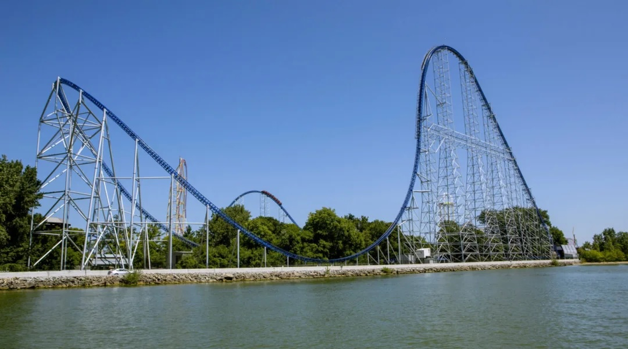

## Limits

Today we will be discussing the foundation of all calculus going forward: the limit.

$$\lim_{x \to a} f(x)$$

Everything we will do in future lectures: derivatives, integrals, all the things you may have heard of in terms of calculus are built off the humble limit.

## Limits

Consider the function $f(x) = x^2$ at the point $x=3$. As $f(x)$ is continuous, as we put $x$’s closer and closer to $3$, we will get values of $f(x)$ closer and closer and closer to $f(3)$.

$$\begin{aligned}
f(2) &= 4 & f(4) &= 16\\
f(2.5) &= 6.25 & f(3.5) &= 12.25\\
f(2.75) &= 7.5625 & f(3.25) &= 10.5625\\
f(2.9) &= 8.41 & f(3.1) &= 9.61 \\
f(2.99) &= 8.9401 & f(3.01) &= 9.0601\\
f(2.999) &= 8.994001 & f(3.001) &= 9.006001 \\
&\vdots & &\vdots \\
f(3) &= 9 & f(3) &= 9
\end{aligned}$$

## Limits

Given a function $f$, a fixed input $x=a$, and a real number $L$, we say that $f$ has limit $L$ as $x$ approaches $a$, and write

$$\lim_{x \to a} f(x) = L,$$

provided that we can make $f(x)$ as close to $L$ as we like by taking $x$ sufficiently close (but not equal) to $a$. If we cannot make $f(x)$ as close to a single value as we would like as $x$ approaches $a$, then we say that $f$ does not have a limit $L$ as $x$ approaches $a$.

## Left-Hand Limits

We say that $f$ has limit $L_1$ as $x$ approached $a$ from the left and write
$$\lim_{x \to a^-} f(x) = L_1$$

provided that we can make the value of $f(x)$ as close to $L_1$ as we like by taking $x$ sufficiently close to $a$, while always having $x < a$. We call $L_1$ the left-hand limit of $f$ as $x$ approaches $a$.

## Right-Hand Limits

We say that $f$ has limit $L_2$ as $x$ approached $a$ from the right and write

$$\lim_{x \to a^+} f(x) = L_2$$

provided that we can make the value of $f(x)$ as close to $L_2$ as we like by taking $x$ sufficiently close to $a$, while always having $x > a$. We call $L_1$ the right-hand limit of $f$ as $x$ approaches $a$.

## Left-Hand and Right-Hand Limits

A function $f$ has limit $L$ as $x \to a$ if and only if

$$\lim_{x \to a^-} f(x) = L = \lim_{x \to a^+} f(x)$$

## Continuity

What does it mean for a function to be continuous? A function $f$ is continuous at $x=a$ provided that:

- $f$ has a limit as $x \to a$,
- $f$ is defined at $x=a$, and
- $\lim\limits_{x \to a} f(x) = f(a)$.

## The Limit Does Not Exist!

There are some situations where a limit simply does not exist.

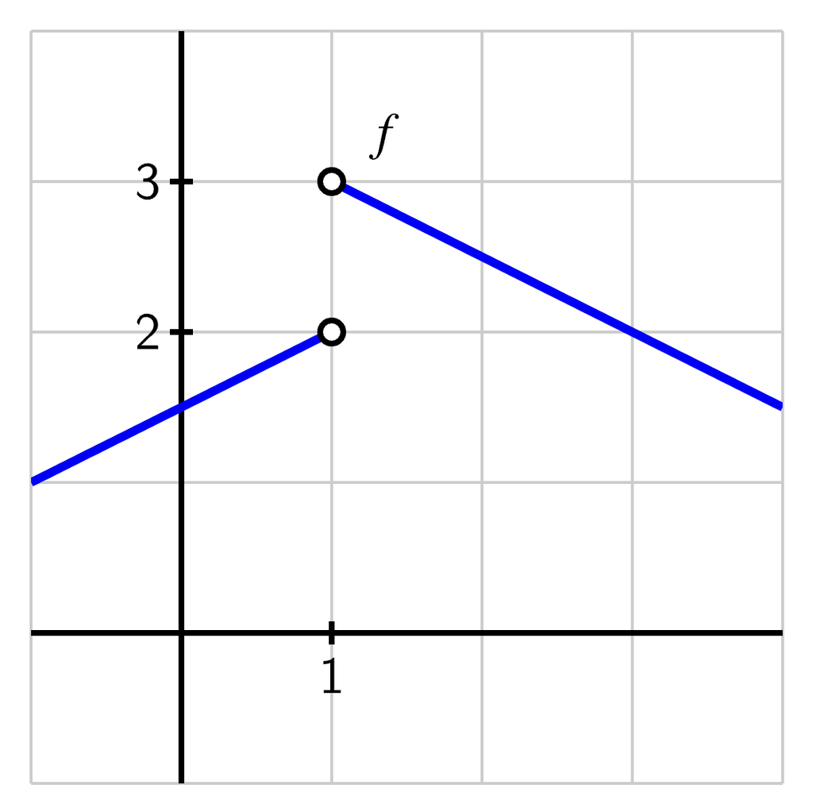

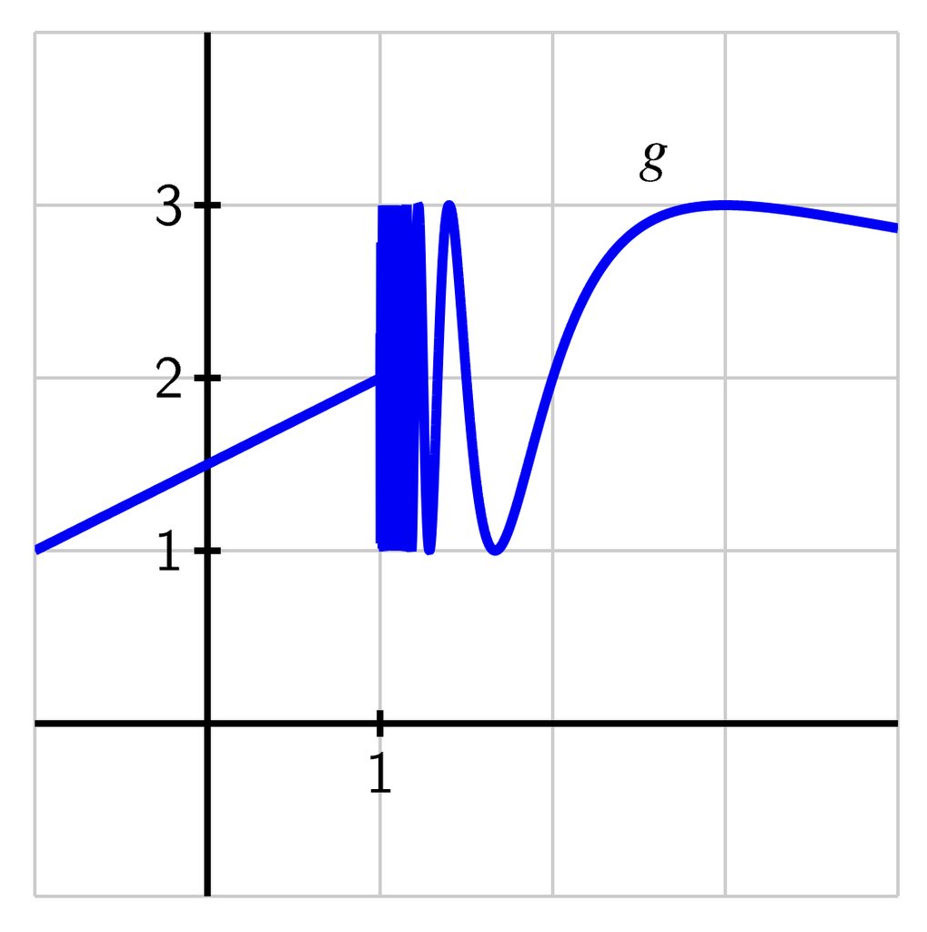

## Limit Examples

**Example:** Try to find the following limits:

1. $\lim\limits_{x \to 1} x^2 + 2$.
2. $\lim\limits_{t \to 0} \dfrac{\sin(5t)}{t}$.
3. $\lim\limits_{y \to 1} \dfrac{x^2 - 1}{x - 1}$.

## Rates of Change

Recall that for a function $f$ defined on an interval $[a, b]$, the average rate of change of $f$ on $[a, b]$ is the quantity

$$AV_{[a, b]} = \frac{f(b) - f(a)} {b - a}.$$

## Instantaneous Rate of Change

If we want to find the instantaneous rate of change at a point $x = a$, imagine the average rate of change over an interval that is getting smaller and smaller and smaller.

For a function $f$, the instantaneous rate of change of $f$ at point $x = a$ is the quantity
$$IV_{t=a} = \lim\limits_{h \to 0} AV_{[a,a+h]} = \lim\limits_{h \to 0} \frac{f(a + h) - f(a)} {h}.$$

## Rates of Change Example

**Example:** Consider $S(x) = x^2 + x + 1$.

- Find $AV_{[0,1]}$.
- Find $AV_{[-1,1]}$.
- Find $IV_{x=0}$.
- Find $IV_{x=1}$.